# DCCaptoneProject_FirstPart

## Ploting the results

Finally, we plot the 30 most frequent one, two and three words in the sample.

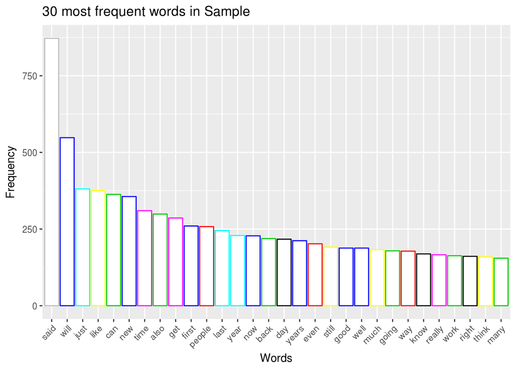

```r
num <- 30
unigram_df <- head(data.frame(terms=names(freq), freq=freq),n=num)
bigram_df <- head(data.frame(terms=names(freq_bigram), freq=freq_bigram),n=num)
trigram_df <- head(data.frame(terms=names(freq_trigram), freq=freq_trigram),n=num)

#Plot 1 - Unigram
plot_unigram  <-ggplot(unigram_df,aes(terms, freq))
plot_unigram  <- plot_unigram  + geom_bar(fill="white",colour=unigram_df$freq,stat="identity") + scale_x_discrete(limits=unigram_df$terms)
plot_unigram  <- plot_unigram  + theme(axis.text.x=element_text(angle=45, hjust=1))
plot_unigram  <- plot_unigram  + labs(x = "Words", y="Frequency", title="30 most frequent words in Sample")
plot_unigram
```

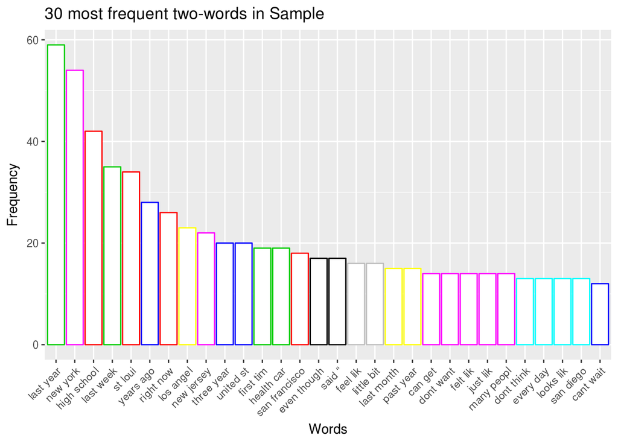

```r
plot_bigram <-ggplot(bigram_df,aes(terms, freq))
plot_bigram <-plot_bigram + geom_bar(fill="white", colour=bigram_df$freq,stat="identity") + scale_x_discrete(limits=bigram_df$terms)
plot_bigram <- plot_bigram + theme(axis.text.x=element_text(angle=45, hjust=1))
plot_bigram<- plot_bigram+ labs(x = "Words", y="Frequency", title="30 most frequent two-words in Sample")
plot_bigram
```

[figure not shown]

```r
plot_trigram <-ggplot(trigram_df,aes(terms, freq))
plot_trigram <- plot_trigram + geom_bar(fill="white",colour=trigram_df$freq,stat="identity") + scale_x_discrete(limits=trigram_df$terms)
plot_trigram <- plot_trigram + theme(axis.text.x=element_text(angle=45, hjust=1))
plot_trigram <- plot_trigram + labs(x = "Words", y="Frequency", title="Top 30 Trigrams in Sample")
plot_trigram
```

## Conclusions and next steps

The next step is to build the predictive algorithm to know the next word which are going to be write in a sentence. The data to be used for training and testing the algorithm is the n-grams we have been building in this projects. The algorithm have to be optimized in order to be executed with low memory and cpu, so the resources have to be measured.